# Hg Screening

24 October, 2017

### Notes

Goal: Check out mercury results…how often are there exceedences?

- Queried AWQMS (171024) for all sites w/ Hg results where the units were in ug/L

### 1.0 Import AWQMS Export file (*abrev.*)

```r
## This code-block only needs to be run when the dataset has changed...
library(openxlsx)
library(lubridate)
file <- choose.files(caption="Select _Working_ DATA file [*.xlsx]", multi = FALSE)
DATA.file0 <- read.xlsx(file, sheet=1, startRow = 1, colNames=TRUE, rowNames=FALSE, detectDates=TRUE);
filename <- basename(file)
path.filename <- dirname(file)
DATA0 <- DATA.file0[,c(-1,-2,-5,-6,-7,-13,-16,-18,-20,-21,-22,-23,-24,-25,-26,-28,
                       -36,-37,-38,-42,-43,-44,-45,-46,-48,-49,-50,-51)]
```

**Dataset Info**::

- **Data File Name:** Standard Export 18607_Hg_all_171024.xlsx
- **Data File Path:** L:/DATA MANAGEMENT & QA/AWQMs & IR Data Checks
- Imported datafile has **51** Columns and **61,369** records

### 2.0 Examine dataset

**Site Types / {Monitoring Location Type}**

- There are 14 unique Site-Types

```r
(unique(DATA0$Monitoring.Location.Type))
```

```
 [1] "River/Stream"             "Facility Other"           "Lake"
 [4] "Spring"                   "Well"                     "Wetland Undifferentiated"
 [7] "Storm Sewer"              "Seep"                     "Canal Drainage"
[10] "Canal Transport"          "Canal Irrigation"         "Other-Ground Water"
[13] "Waste Sewer"              "Mine/Mine Discharge"
```

**Activity Types**

- There are 3 unique Activity Types

```r
(unique(DATA0$Activity.Type))
```

```
[1] "Sample-Routine"                     "Sample-Integrated Vertical Profile"
[3] "Sample-Composite Without Parents"
```

**Monitoring Locations**

- There are 4571 unique Sites

**Sampling Dates**

- Earliest Sampling Date :: (1974-04-24)
- Most recent Sampling Date :: (2016-09-22)

**Relative Depth of Sample**

- There are 7 unique Relative Depths

```r
(unique(DATA0$Relative.Depth))
```

```
[1] NA                "Surface"         "Bottom"          "Midwater"
[5] "AboveThermoclin" "BelowThermoclin" "Near Bottom"
```

```r
as.data.frame(table(DATA0$Relative.Depth, useNA = "ifany"))
```

| Var1 | Freq |
| --- | --- |
| AboveThermoclin | 43 |
| BelowThermoclin | 34 |
| Bottom | 3373 |
| Midwater | 1040 |
| Near Bottom | 8 |
| Surface | 12842 |
| NA | 44029 |

**Sample Fractions / Matrix**

- There are 3 unique Sample Fractions

```r
unique(DATA0$Sample.Fraction)
```

```
[1] "Acid Soluble" "Dissolved"    "Total"
```

```r
as.data.frame(table(DATA0$Sample.Fraction, useNA = "ifany"))
```

| Var1 | Freq |
| --- | --- |
| Acid Soluble | 25467 |
| Dissolved | 33130 |
| Total | 2772 |

```r
addmargins(table(DATA0$Monitoring.Location.Type, DATA0$Sample.Fraction, useNA = "ifany"))
```

```
                           Acid Soluble Dissolved Total   Sum
  Canal Drainage                    558       332    63   953
  Canal Irrigation                   36        27     0    63
  Canal Transport                   458       241    21   720
  Facility Other                    808       815   790  2413
  Lake                             3458      3702   324  7484
  Mine/Mine Discharge                 1        14    13    28
  Other-Ground Water                 60         9     0    69
  River/Stream                    19087     25074   798 44959
  Seep                               20        21    24    65
  Spring                            604       647   230  1481
  Storm Sewer                        18       174     0   192
  Waste Sewer                        83       150     0   233
  Well                              167      1357   410  1934
  Wetland Undifferentiated          109       567    99   775
  Sum                             25467     33130  2772 61369
```

**Detection Condition / Result-Flags**

```r
data.frame(DetCond = table(DATA0$Detection.Condition, useNA = "ifany"))
```

| DetCond.Var1 | DetCond.Freq |
| --- | --- |
| Not Detected | 57669 |
| Present Above Quantification Limit | 32 |
| NA | 3668 |

**Drop any cases where DetCon = “Present Above Quantification Limit”**

**Result Units**

- There are 1 unique Result Units
  - ug/l

**Null Result-Values**

- There are 57701 records where Result Value is missing / *NULL*

**Types of Quantitation / Reporting Limits**

- There are 5 unique Reporting Limits

```r
unique(DATA0$Detection.Limit.Type1)
```

```
[1] "Method Detection Level"   "Lower Reporting Limit"    NA
[4] "Lower Quantitation Limit" "Upper Quantitation Limit"
```

```r
data.frame(DetLim.Type = table(DATA0$Detection.Limit.Type1, useNA = "ifany"))
```

| DetLim.Type.Var1 | DetLim.Type.Freq |
| --- | --- |
| Lower Quantitation Limit | 13835 |
| Lower Reporting Limit | 11476 |
| Method Detection Level | 32591 |
| Upper Quantitation Limit | 32 |
| NA | 3435 |

**Range of values of MDL / LRLs**

- “Method Detection Level” :: 0 to 20
- “Lower Reporting Limit” :: 0.2 to 0.2
- “Lower Quantitation Limit” :: -0.1 to 2
- “Upper Quantitation Limit” :: 0.1 to 0.2

*Note that all these levels / limits are much greater that the numeric criterion for aquatic life (0.012 ug/L; 2.0 ug/L for DW (BUC 1C))*

### 3.0 Select Data

```r
htmlTable::htmlTable(as.data.frame(table(DATA0$Monitoring.Location.Type[!is.na(DATA0$Result.Value)], useNA = "ifany")), rnames=FALSE)
```

| Var1 | Freq |
| --- | --- |
| Canal Drainage | 108 |
| Canal Irrigation | 10 |
| Canal Transport | 35 |
| Facility Other | 303 |
| Lake | 720 |
| Other-Ground Water | 1 |
| River/Stream | 2290 |
| Seep | 1 |
| Spring | 75 |
| Storm Sewer | 2 |
| Waste Sewer | 15 |
| Well | 43 |
| Wetland Undifferentiated | 65 |

```r
# recode MONLOC.Type to fewer groups
DATA0$Site.Type <- ifelse(DATA0$Monitoring.Location.Type == "Canal Drainage" |
                DATA0$Monitoring.Location.Type == "Canal Irrigation" |
                DATA0$Monitoring.Location.Type == "Canal Transport", "Canal",
            ifelse(DATA0$Monitoring.Location.Type == "Facility Other" |
                       DATA0$Monitoring.Location.Type == "Storm Sewer" |
                       DATA0$Monitoring.Location.Type == "Waste Sewer", "Facility",
            ifelse(DATA0$Monitoring.Location.Type == "Wetland Undifferentiated" |
                       DATA0$Monitoring.Location.Type == "Seep" |
                       DATA0$Monitoring.Location.Type == "Spring", "Wetland",
            ifelse(DATA0$Monitoring.Location.Type == "Other-Ground Water" |
                       DATA0$Monitoring.Location.Type == "Well" |
                       DATA0$Monitoring.Location.Type == "Mine/Mine Discharge", "GW",
            ifelse(DATA0$Monitoring.Location.Type == "Lake", "Lake",
                   ifelse(DATA0$Monitoring.Location.Type == "River/Stream", "Stream", "missing"))))))
#
## Clean out any RV's = 0 or MDLs < 0
DATA0$Result.Value <- as.numeric(DATA0$Result.Value)
DATA0$Result.Value2 <- ifelse(!is.na(DATA0$Result.Value),
                             ifelse(DATA0$Result.Value == 0, NA,
                                    as.numeric(DATA0$Result.Value)), NA)
DATA0$Detection.Limit.Value1 <- as.numeric(DATA0$Detection.Limit.Value1)
DATA0$Detection.Limit.Value2 <- ifelse(!is.na(DATA0$Detection.Limit.Value1),
                             ifelse(DATA0$Detection.Limit.Value1 <= 0, NA,
                                    as.numeric(DATA0$Detection.Limit.Value1)), NA)
#
DATA0$RESULT_x <- ifelse(!is.na(DATA0$Result.Value2), as.numeric(DATA0$Result.Value2),
                         ifelse(!is.na(DATA0$Detection.Limit.Value2),
                                as.numeric(DATA0$Detection.Limit.Value2),
                                NA))
```

### 4.0 Inspect data patterns

```r
# Subset data
DATA.hg <- DATA0[(!is.na(DATA0$RESULT_x) & DATA0$Site.Type != "missing" & (is.na(DATA0$Detection.Condition) | DATA0$Detection.Condition != "Present Above Quantification Limit")),]
```

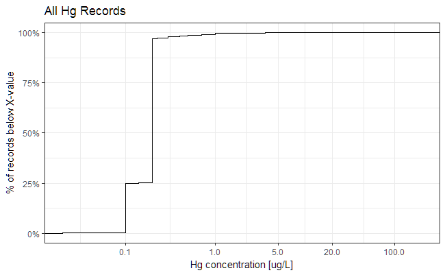

```r
library(ggplot2); library(scales);
z <- ggplot(data = DATA.hg) + theme_bw()
z0 <- z + stat_ecdf(aes(x=(RESULT_x)), na.rm=T) + ggtitle("All Hg Records") +
    scale_x_continuous(trans = "log10", breaks = c(0.012, 0.1, 1.0, 5, 20, 100), limits=c(NA, 200), oob=squish) + scale_y_continuous(labels=percent) +
    xlab("Hg concentration [ug/L]") + ylab("% of records below X-value")
z0
```

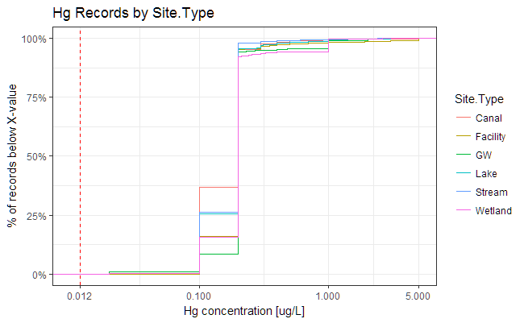

```r
library(ggplot2); library(scales);
z <- ggplot(data = DATA.hg) + theme_bw()
z0 <- z + stat_ecdf(aes(x=(RESULT_x), color=Site.Type), na.rm=T) +
    ggtitle("Hg Records by Site.Type") +
    scale_x_continuous(trans = "log10", breaks = c(0.001, 0.012, 0.1, 1.0, 5, 20, 100), limits=c(0.01, 5), oob=squish) + scale_y_continuous(labels=percent) +
    xlab("Hg concentration [ug/L]") + ylab("% of records below X-value") +
    geom_vline(xintercept=0.012, lty=2, color="red")
z0
```

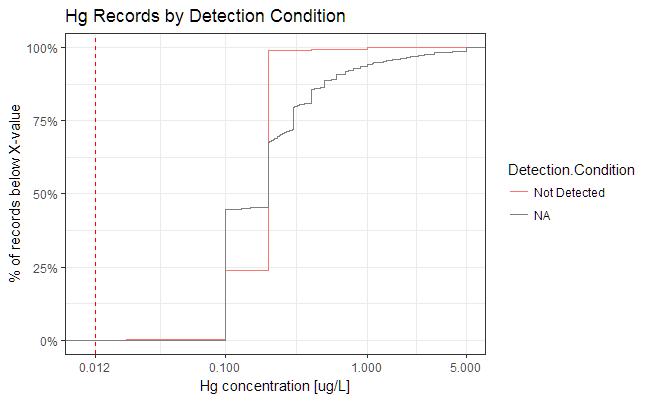

```r
#
library(ggplot2); library(scales);
z <- ggplot(data = DATA.hg) + theme_bw()
z0 <- z + stat_ecdf(aes(x=(RESULT_x), color=Detection.Condition)) +
    ggtitle("Hg Records by Detection Condition") +
    scale_x_continuous(trans = "log10", breaks = c(0.012, 0.1, 1.0, 5, 20, 100), limits=c(0.01, 5), oob=squish) + scale_y_continuous(labels=percent) +
    xlab("Hg concentration [ug/L]") + ylab("% of records below X-value") + geom_vline(xintercept=0.012, lty=2, color="red")
z0
```

Total number of ‘non-detect’ records :: 57,665

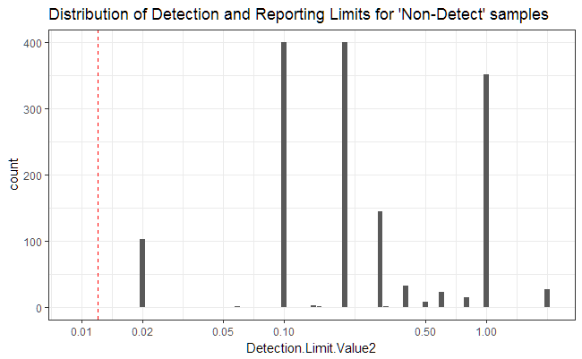

```r
DATA.hg2 <- DATA.hg[!is.na(DATA.hg$Detection.Condition),]
#
ggplot(data=DATA.hg2) + stat_count(aes(x=Detection.Limit.Value2), na.rm=T) + scale_x_continuous(limits=c(0.009,2.1), trans="log10", breaks = c(0.01,0.02, 0.05, 0.1, 0.5, 1.0)) + scale_y_continuous(limits = c(0,400), oob=squish) + ggtitle("Distribution of Detection and Reporting Limits for 'Non-Detect' samples") + theme_bw() + geom_vline(xintercept=0.012, lty=2, color="red")
```

- Number of samples greater than Detection Limits :: 3,654
  - Number of these records where Result.value < numeric criteria (0.012 ug/L) :: 0
  - **All sample hits (quantitated result values) exceeded numeric criteria**
- Proportion of records where result was detected :: 5.96%